# Survey, Experience & Participation Codebook

## What this notebook is

This notebook takes the surveys and spreadsheets the Ranch collects every year and turns them into clear charts and findings about the participant and staff experience. It answers questions like: *Who is actually responding to our surveys? What do people love and what do they complain about? Are staff coming back? Is our overall experience rating strong? Is the cost of a trek affecting how many crews show up?*

**You do not need to know how to code to use this.** Everything is already written. Your job each year is to swap in the new spreadsheets, press "Run all," and read the charts and write-ups that come out. The sections below walk you through it.

## Workflow Overview

Here is the whole notebook in plain English, top to bottom:

1. **Connect to Google Drive** — so the notebook can find your spreadsheets.
2. **Load the tools** — turns on the free software that reads Excel files and draws charts.
3. **Load + clean all the files** — opens every survey, fixes messy column names, and turns words like "Excellent / Good / Fair / Poor" into numbers (4 / 3 / 2 / 1) so they can be averaged.
4. **Answer the research questions one at a time** — survey response bias, what people praise and complain about, staff return rates, the overall experience score (NPS), backcountry camps, brand awareness, and more. Each question prints its findings and draws a chart.
5. **The "big picture" sections** — historical participation back to 2019, the fee-vs-participation relationship, outside validation from Reddit and national BSA membership, and a few appendix checks.
6. **All the final presentation charts in one place** — the polished images used on the slides.

Each step prints its results right underneath it, so you can read the story as you scroll.

## Directions for how to replicate this in the easiest way

This is the part to read carefully if you are running it for the first time, or handing it to the next person. It is written so a non-coder can do it.

**1. Put this year's files in one folder on Google Drive.** Make a folder in your Google Drive (for example `the Ranch Capstone Data 2026`) and drop in every spreadsheet the Ranch gave you this year: the staff survey, the trek/base-camp survey, the conservation and ranger surveys, the response-rate file, the brand-awareness file, the fee schedule, and the participation zip. **Keep the file names as close as possible to the originals.**

**2. Open this notebook in Google Colab and connect your Drive.** Run the very first code cell (the "Connect to Google Drive" one). A pop-up will ask for permission — say yes. This is what lets the notebook see your files.

**3. Change ONE line: the folder location.** In the **"Load + clean all the files"** step there is a line that starts with `data_dir =`. That is the address of your folder on Google Drive. Change the text inside the quotes so it points to *your* folder for this year. This is the single most important thing to update.

**4. Make sure the file names inside the quotes match your files.** A little further down, each file is opened by name (for example `"internal seasonal-staff survey export"`). If the Ranch renamed a file this year, update the name inside the quotes so it matches exactly — spelling, spaces, and the `.xlsx` at the end all have to match. **The easiest trick:** open your Drive folder in one window and copy the file name straight from there so there are no typos.

**5. Press "Run all."** At the top of Colab, click **Runtime → Run all**. The notebook runs every step in order and fills in all the charts and findings. Then just scroll and read.

**6. Update chart titles and labels if your numbers changed.** The titles on the charts (and the year labels like "2025") are written inside the code. They are easy to find and edit — they are always inside quotes. To keep this notebook clean I have not flagged every single one, so before you share the results, skim the charts and fix any title or year that should say something different for this year's data.

**7. Stuck? Use Gemini or Google.** If you hit an error, copy the red error message and paste it into Gemini (Google's free AI helper) and ask "how do I fix this?" It is very good at helping non-coders. Searching the error on Google works too. And of course you can always reach back out to the student analyst who built this — contact info is below.

## Critical Tips for Success (read these if it's your first time)

Keep these three things in mind and the notebook will almost always run cleanly:

1. **Run the cells in order.** If you ever see an error that says **`NameError`**, it almost always means a step above was skipped. The fix is simple: go to **Runtime → Run all** so every step runs top to bottom.
2. **File names and column names must match exactly.** The notebook looks for files and columns by their exact name. If the Ranch changes a spreadsheet's name or renames a column header, update the matching text (inside the quotes) in the loading step. A single extra space or a different capital letter will stop it.
3. **Only edit text inside quotation marks.** Almost everything you ever need to change — folder locations, file names, chart titles, year labels — lives inside `'single'` or `"double"` quotes. If it is not inside quotes, you probably do not need to touch it.

## A note on the data sources

Every chart in this notebook comes from a real the Ranch file. Toward the end there is a section that lists, chart by chart, exactly which spreadsheet each one came from and how many responses it is based on, so anyone reviewing the work can trace every number back to its source.

# **Questions later?**

#### Reach out to the analyst who built this, he is happy to help future teams pick it back up. the project team

## 1. Connect to Google Drive

**What this does:** This is the very first thing to run. It connects the notebook to your Google Drive so it can find your spreadsheets. When you run it, a pop-up appears asking for permission — click through and say **Allow**.

**What to change:** Nothing. Just run it once at the start of every session.

```python
# ═══════════════════════════════════════════════════════════════
# CELL 0: Mount Google Drive
# ═══════════════════════════════════════════════════════════════
from google.colab import drive
drive.mount('/content/drive')
```

## 2. Load the tools

**What this does:** This turns on the free, built-in software the notebook needs — the part that reads Excel files, the part that does the math, and the part that draws the charts. Think of it as getting all your equipment out of the closet before you start.

**What to change:** Nothing. Run it and move on.

```python
# ═══════════════════════════════════════════════════════════════
# CELL 1: Imports
# ═══════════════════════════════════════════════════════════════
import pandas as pd
import zipfile
import os
import re
from collections import Counter
import matplotlib.pyplot as plt
import matplotlib.ticker as mticker
import numpy as np
```

## 3. Load and clean all the files

**This is the most important step to customize.** Everything else depends on it.

**What this does, in plain English:**

- Opens every the Ranch survey spreadsheet for the year.
- Cleans up messy column headers (surveys often come out with names like `Unnamed: 6`, so this step renames them to something readable like `ranger_first_aid`).
- Converts word-ratings into numbers so they can be averaged: **Excellent = 4, Good = 3, Fair = 2, Poor = 1**.
- Reads the "X of Y responded" response-rate text and turns it into an actual percentage.
- Unzips the participation file and loads the year-to-year comparison sheets.

**What to change (the two things that matter most):**

1. **`data_dir`** — the line near the top inside quotes. Change it to point to *your* Google Drive folder for this year's data.
2. **The file names** — each `pd.read_excel(...)` and `pd.read_csv(...)` line has a file name inside quotes. Make sure each one matches the real file name in your folder exactly (copy the name straight from Drive to avoid typos).

**Tip:** I recommend keeping the names I gave the data tables (the `df_staff`, `df_basecamp`, etc.). Later steps refer back to those names, so if you rename them here you would have to rename them everywhere. Easiest to leave them alone.

```python
# ═══════════════════════════════════════════════════════════════
# CELL 2: Load + Clean All Files
# ═══════════════════════════════════════════════════════════════

data_dir = "./data"
#Change data directory to wherever in your Google Drive you have the data
def profile_df(df, label):
    print(f"\n{'='*60}")
    print(f"FILE: {label}")
    print(f"{'='*60}")
    print(f"Shape: {df.shape[0]:,} rows × {df.shape[1]} columns")
    print(f"\nColumns: {df.columns.tolist()}")
    missing = df.isnull().sum()
    missing_pct = (missing / len(df) * 100).round(1)
    missing_df = pd.DataFrame({'missing_count': missing, 'missing_%': missing_pct})
    missing_df = missing_df[missing_df['missing_count'] > 0]
    if not missing_df.empty:
        print(f"\nMissing Values:\n{missing_df}")
    else:
        print("\nMissing Values: None ✓")

# ── STEP 1: LOAD ALL FILES ────────────────────────────────────
df_staff = pd.read_excel(f"{data_dir}/internal seasonal-staff survey export")
df_basecamp = pd.read_excel(f"{data_dir}/2025 Trek Survey Results Combined - Base Camp &  Backcountry (As of 11-20-25).xlsx", header=1)
df_conservation = pd.read_excel(f"{data_dir}/2025 Trek Survey Results Combined - Conservation (as of 11-20-25).xlsx")
df_ranger = pd.read_excel(f"{data_dir}/2025 Trek Survey Results Combined - Ranger (as of 11-20-25).xlsx")
df_response_rates = pd.read_excel(f"{data_dir}/internal trek-survey response export")
df_brand = pd.read_csv(f"{data_dir}/High adventure knowledge and experience data 2025.csv")

print("✅ All files loaded successfully!")

# ── STEP 2a: STAFF SURVEY ─────────────────────────────────────
df_staff = df_staff.drop(columns=['Name'])

leadership_roles = ['Director', 'Manager', 'Team Lead']
df_staff['is_leadership'] = df_staff['Were you in a management role or a general staff position?'].apply(
    lambda x: any(role in str(x) for role in leadership_roles)
)
print(f"\nStaff — Leadership: {df_staff['is_leadership'].sum()}, General: {(~df_staff['is_leadership']).sum()}")

# ── STEP 2b: CONSERVATION — rename confirmed sub-questions ────
conservation_rename = {
    'Please Rate your experience with conservation project staff': 'conservation_staff_interpersonal',
    'Unnamed: 6':  'conservation_staff_time_management',
    'Unnamed: 7':  'conservation_staff_safety_risk',
    'Unnamed: 8':  'conservation_staff_knowledge',
    'Unnamed: 9':  'conservation_staff_overall',
    'Please Rate your experience at your conservation project': 'conservation_project_impact',
    'Unnamed: 11': 'conservation_project_equipment',
    'Unnamed: 12': 'conservation_project_overall',
}
df_conservation = df_conservation.rename(columns=conservation_rename)
print("Conservation columns renamed ✓")

# ── STEP 2c: RANGER — confirmed sub-question labels ───────────
ranger_rename = {
    "Please Rate your satisfaction with your ranger's instruction and processes in the following areas": 'ranger_base_camp_process',
    'Unnamed: 6':  'ranger_shakedown',
    'Unnamed: 7':  'ranger_weather_safety',
    'Unnamed: 8':  'ranger_navigation',
    'Unnamed: 9':  'ranger_waste_disposal',
    'Unnamed: 10': 'ranger_hiking_etiquette',
    'Unnamed: 11': 'ranger_campsite_setup',
    'Unnamed: 12': 'ranger_wildlife_procedures',
    'Unnamed: 13': 'ranger_backcountry_cooking',
    'Unnamed: 14': 'ranger_water_purification',
    'Unnamed: 15': 'ranger_first_aid',
    'Unnamed: 16': 'ranger_leave_no_trace',
    'Unnamed: 17': 'ranger_interpersonal_skills',
    'Unnamed: 18': 'ranger_care_for_crew',
    'Unnamed: 19': 'ranger_efficient_time',
    'Unnamed: 20': 'ranger_youth_leadership',
    # Unnamed: 21 is the yes/no dispersed camping question — not a rating
    "Please Rate your satisfaction with your ranger's instruction and processes in the following areas.1": 'ranger_low_impact_camping',
}
df_ranger = df_ranger.rename(columns=ranger_rename)
print("Ranger columns renamed with confirmed labels ✓")

# ── STEP 2d: CONVERT RATINGS TO NUMERIC ───────────────────────
rating_map = {'Excellent': 4, 'Good': 3, 'Fair': 2, 'Poor': 1}

conservation_staff_cols = [
    'conservation_staff_interpersonal', 'conservation_staff_time_management',
    'conservation_staff_safety_risk', 'conservation_staff_knowledge',
    'conservation_staff_overall'
]
conservation_project_cols = [
    'conservation_project_impact', 'conservation_project_equipment',
    'conservation_project_overall'
]
ranger_cols = [
    'ranger_base_camp_process', 'ranger_shakedown', 'ranger_weather_safety',
    'ranger_navigation', 'ranger_waste_disposal', 'ranger_hiking_etiquette',
    'ranger_campsite_setup', 'ranger_wildlife_procedures', 'ranger_backcountry_cooking',
    'ranger_water_purification', 'ranger_first_aid', 'ranger_leave_no_trace',
    'ranger_interpersonal_skills', 'ranger_care_for_crew', 'ranger_efficient_time',
    'ranger_youth_leadership'
    # ranger_low_impact_camping excluded from avg — conditional question
    # only applies to crews that camped in dispersed locations
]

for col in conservation_staff_cols + conservation_project_cols:
    df_conservation[col] = df_conservation[col].map(rating_map)

for col in ranger_cols:
    df_ranger[col] = df_ranger[col].map(rating_map)

df_conservation['staff_rating_avg'] = df_conservation[conservation_staff_cols].mean(axis=1)
df_conservation['project_rating_avg'] = df_conservation[conservation_project_cols].mean(axis=1)
df_ranger['ranger_rating_avg'] = df_ranger[ranger_cols].mean(axis=1)

# Add after the ranger_cols conversion loop
df_ranger['ranger_low_impact_camping'] = df_ranger['ranger_low_impact_camping'].map(rating_map)

# ── STEP 2e: DECODE ITINERARY ─────────────────────────────────
def parse_itinerary(val):
    val = str(val).strip()
    if len(val) > 8 and '-' in val:
        return None, None, False
    match = re.match(r'(\d+)-(\d+)(\*?)', val)
    if match:
        return int(match.group(1)), int(match.group(2)), match.group(3) == '*'
    return None, None, False

for df, name in [(df_conservation, 'conservation'), (df_ranger, 'ranger')]:
    df[['trek_length', 'trek_difficulty', 'trek_variant']] = df['Itinerary'].apply(
        lambda x: pd.Series(parse_itinerary(x))
    )

# ── STEP 2f: RESPONSE RATE TRACKER ───────────────────────────
def parse_response(val):
    if pd.isna(val): return None, None, None
    match = re.match(r'(\d+) of (\d+)', str(val))
    if match:
        responded, total = int(match.group(1)), int(match.group(2))
        return responded, total, round(responded/total, 3) if total > 0 else 0
    return None, None, None

for col in ['Adult Responses', 'Youth Responses']:
    df_response_rates[[f'{col}_n', f'{col}_total', f'{col}_rate']] = df_response_rates[col].apply(
        lambda x: pd.Series(parse_response(x))
    )

# ── STEP 2g: BRAND AWARENESS — shorten column names ──────────
brand_rename = {
    df_brand.columns[2]: 'familiar_program',
    df_brand.columns[3]: 'familiar_sea_base',
    df_brand.columns[4]: 'familiar_summit',
    df_brand.columns[5]: 'familiar_northern_tier',
    df_brand.columns[6]: 'attendance_status',
    df_brand.columns[7]: 'barrier_to_attend',
    df_brand.columns[8]: 'barrier_other_text',
}
df_brand = df_brand.rename(columns=brand_rename)

familiarity_map = {
    'Very familiar, I  or my troop has been there before and I know about the programs/experiences offered.': 4,
    'Familiar, I  or my troop have not been there (or it has been a long time since we have been), but I have heard about the programs/experiences offered': 3,
    'Not very familiar, I have heard a little but don\'t really know much about the programs/experiences offered': 2,
    'Not at all familiar, I don\'t know about the programs/experiences offered at this base.': 1,
}
familiarity_cols = ['familiar_program', 'familiar_sea_base', 'familiar_summit', 'familiar_northern_tier']
base_names = ['the Ranch', 'Florida Sea Base', 'The Summit', 'Northern Tier']
for col in familiarity_cols:
    df_brand[col + '_score'] = df_brand[col].map(familiarity_map)

# ── STEP 2h: BASE CAMP — convert ratings + rename NPS ─────────
basecamp_ops_cols = [
    'Welcome Center', 'Medical Recheck', 'Outfitting Services', 'Mail Room',
    'Main Trading Post', 'Crew Photo', 'Religious Services',
    'Opening Campfire', 'Closing Campfire', 'Base Camp Customer Service',
    'Base Camp Facilities', 'Overall Base Camp Experience'
]
food_cols = [
    'Dining Hall Food Quality', 'Dining Hall Food Quantity', 'Dining Hall Food Overall',
    'Trail Meal Quality', 'Trail Meal Quantity', 'Trail Meal Variety',
    'Specialty Meal Experience (Chuckwagon, Mexican Dinner, etc)',
    'Backcountry Meals Overall'
]
backcountry_general_cols = [
    'Staffed Camp Facilities', 'Trail Camp Facilities', 'Trails',
    'Backcountry Trading Posts/Cantinas', 'Backcountry Commissaries',
    'Overall Backcountry Experience'
]

for col in basecamp_ops_cols + food_cols + backcountry_general_cols:
    if col in df_basecamp.columns:
        df_basecamp[col] = df_basecamp[col].map(rating_map)

df_basecamp['basecamp_ops_avg'] = df_basecamp[basecamp_ops_cols].mean(axis=1)
df_basecamp['food_avg'] = df_basecamp[food_cols].mean(axis=1)
df_basecamp['backcountry_avg'] = df_basecamp[backcountry_general_cols].mean(axis=1)

df_basecamp = df_basecamp.rename(columns={
    'Unnamed: 87': 'nps_adults',
    'Unnamed: 88': 'nps_scouts',
})
df_basecamp['nps_adults'] = pd.to_numeric(df_basecamp['nps_adults'], errors='coerce')
df_basecamp['nps_scouts'] = pd.to_numeric(df_basecamp['nps_scouts'], errors='coerce')

# ── STEP 2i: EXTRACT PARTICIPATION ZIP ────────────────────────
extract_dir = f"{data_dir}/participation_data"
os.makedirs(extract_dir, exist_ok=True)
with zipfile.ZipFile(f"{data_dir}/internal participation-data export", 'r') as z:
    z.extractall(extract_dir)

participation_frames = {}
for fname in sorted(os.listdir(extract_dir)):
    if fname.endswith('.xlsx'):
        participation_frames[fname] = pd.read_excel(os.path.join(extract_dir, fname))

# ── STEP 2j: LOAD PARTICIPANT FEEDBACK COMPARISON ─────────────
feedback_path = f"{data_dir}/internal participant-feedback comparison export"
df_2025_raw = pd.read_excel(feedback_path, sheet_name='2025', header=None)
df_2024_raw = pd.read_excel(feedback_path, sheet_name='2024', header=None)

print("\n✅ Cell 2 complete — all files loaded and cleaned")
```

```
✅ All files loaded successfully!

Staff — Leadership: 55, General: 253
Conservation columns renamed ✓
Ranger columns renamed with confirmed labels ✓

✅ Cell 2 complete — all files loaded and cleaned
```

## Research Question 1 — Who is actually answering our surveys?

**What this does:** Before trusting any survey result, you have to know *who responded*. This step checks how many crews actually filled out the survey, and compares **adult** response rates to **youth** response rates. It turns out adults respond far more often than youth, which means youth voices are underrepresented — something to keep in mind when reading every other finding.

**What to read:** The printout tells you the share of crews with 0% response, with full response, and the average response rates. The interpretation at the bottom spells out what it means.

**What to change:** Nothing needed to re-run. (If you want, you can tweak the wording in the `INTERPRETATION` block at the bottom to match this year's numbers.)

```python
# ═══════════════════════════════════════════════════════════════
# CELL 3: Q1 — Survey Response Bias Analysis
# ═══════════════════════════════════════════════════════════════

print("=" * 60)
print("Q1: SURVEY RESPONSE BIAS ANALYSIS")
print("=" * 60)

total_crews = len(df_response_rates)
print(f"\nTotal crews in dataset: {total_crews:,}")

print("\nAdult response rate distribution:")
print(df_response_rates['Adult Responses_rate'].describe())

print("\nYouth response rate distribution:")
print(df_response_rates['Youth Responses_rate'].describe())

adult_zero = df_response_rates[df_response_rates['Adult Responses_rate'] == 0]
youth_zero = df_response_rates[df_response_rates['Youth Responses_rate'] == 0]
adult_full = df_response_rates[df_response_rates['Adult Responses_rate'] == 1.0]
youth_full = df_response_rates[df_response_rates['Youth Responses_rate'] == 1.0]
df_response_rates['adult_over_100pct'] = df_response_rates['Adult Responses_rate'] > 1.0

print(f"\nCrews with 0% adult response:    {len(adult_zero)} ({round(len(adult_zero)/total_crews*100,1)}%)")
print(f"Crews with 0% youth response:    {len(youth_zero)} ({round(len(youth_zero)/total_crews*100,1)}%)")
print(f"Crews with 100% adult response:  {len(adult_full)}")
print(f"Crews with 100% youth response:  {len(youth_full)}")
print(f"Crews with >100% adult response: {df_response_rates['adult_over_100pct'].sum()} (possible duplicates)")

print("""
INTERPRETATION:
- Survey data is significantly biased toward crews where leaders
  actively encouraged participation
- Youth responses are especially sparse (avg 16%) — youth findings
  should be interpreted with extra caution
- Adults were 2.6x more likely to respond than youth
- Recommend the Ranch standardize survey collection protocols
""")
print("✅ Cell 3 complete")
```

```
============================================================
Q1: SURVEY RESPONSE BIAS ANALYSIS
============================================================

Total crews in dataset: 1,653

Adult response rate distribution:
count    1653.000000
mean        0.423452
std         0.281542
min         0.000000
25%         0.250000
50%         0.333000
75%         0.667000
max         1.333000
Name: Adult Responses_rate, dtype: float64

Youth response rate distribution:
count    1653.000000
mean        0.158943
std         0.173789
min         0.000000
25%         0.000000
50%         0.143000
75%         0.250000
max         1.000000
Name: Youth Responses_rate, dtype: float64

Crews with 0% adult response:    279 (16.9%)
Crews with 0% youth response:    653 (39.5%)
Crews with 100% adult response:  111
Crews with 100% youth response:  2
Crews with >100% adult response: 3 (possible duplicates)

INTERPRETATION:
- Survey data is significantly biased toward crews where leaders
  actively encouraged participation
- Youth responses are especially sparse (avg 16%) — youth findings
  should be interpreted with extra caution
- Adults were 2.6x more likely to respond than youth
- Recommend the Ranch standardize survey collection protocols

✅ Cell 3 complete
```

### Question 1, deeper look — Do youth and adults experience the Ranch *differently*?

**What this does:** This was a follow-up question from the intermediate presentation. Since adults answer surveys more than youth, do the two groups actually *rate things differently*? This step compares youth vs. adult ratings on conservation, rangers, and the overall recommendation score, and even runs a quick statistical test to see whether the gaps are real or just noise.

**What you'll see:** A three-panel chart and a written summary. The interesting finding: rangers actually connect *better* with youth than adult-heavy survey data alone would suggest.

**What to change:** Nothing required. The two NPS numbers near the top (`adult_nps` and `scout_nps`) are written in by hand so this step can stand on its own — if your overall scores change a lot in a future year, update those two numbers to match.

```python
# ═══════════════════════════════════════════════════════════════
# CELL 3b: Q1 — BIAS IMPACT ANALYSIS
# Does the adult vs youth response gap actually change findings?
# follow-up question from the intermediate presentation
# ═══════════════════════════════════════════════════════════════

print("=" * 60)
print("Q1b: BIAS IMPACT — DO YOUTH AND ADULTS SEE IT DIFFERENTLY?")
print("=" * 60)

# NPS values referenced from Cell 6 Q3/Q4 analysis
# Hardcoded here so Cell 3b is self contained when running all cells
adult_nps = 81.6
scout_nps = 78.0

# ── Conservation ratings — Youth vs Adult ─────────────────────
print("\nConservation ratings — Youth vs Adult:")
conservation_bias = df_conservation.groupby('Youth or Adult')[
    ['staff_rating_avg', 'project_rating_avg']
].agg(['mean', 'count', 'std']).round(3)
print(conservation_bias)

# Calculate gap
youth_cons_staff = df_conservation[df_conservation['Youth or Adult'] == 'Youth']['staff_rating_avg'].mean()
adult_cons_staff = df_conservation[df_conservation['Youth or Adult'] == 'Adult']['staff_rating_avg'].mean()
youth_cons_project = df_conservation[df_conservation['Youth or Adult'] == 'Youth']['project_rating_avg'].mean()
adult_cons_project = df_conservation[df_conservation['Youth or Adult'] == 'Adult']['project_rating_avg'].mean()

print(f"\nConservation staff rating gap (Adult - Youth):   {round(adult_cons_staff - youth_cons_staff, 3)}")
print(f"Conservation project rating gap (Adult - Youth): {round(adult_cons_project - youth_cons_project, 3)}")

# ── Ranger ratings — Youth vs Adult ──────────────────────────
print("\nRanger ratings — Youth vs Adult:")
ranger_bias = df_ranger.groupby('Youth or Adult')[
    'ranger_rating_avg'
].agg(['mean', 'count', 'std']).round(3)
print(ranger_bias)

youth_ranger = df_ranger[df_ranger['Youth or Adult'] == 'Youth']['ranger_rating_avg'].mean()
adult_ranger = df_ranger[df_ranger['Youth or Adult'] == 'Adult']['ranger_rating_avg'].mean()
print(f"\nRanger rating gap (Adult - Youth): {round(adult_ranger - youth_ranger, 3)}")

# ── Ranger sub-question gaps ──────────────────────────────────
print("\nRanger sub-question ratings — Youth vs Adult:")
ranger_subq_bias = df_ranger.groupby('Youth or Adult')[ranger_cols].mean().round(3)
print(ranger_subq_bias.T)

# Find biggest gaps
gaps = {}
for col in ranger_cols:
    youth_avg = df_ranger[df_ranger['Youth or Adult'] == 'Youth'][col].mean()
    adult_avg = df_ranger[df_ranger['Youth or Adult'] == 'Adult'][col].mean()
    gaps[col.replace('ranger_', '').replace('_', ' ').title()] = round(adult_avg - youth_avg, 3)

gaps_sorted = sorted(gaps.items(), key=lambda x: abs(x[1]), reverse=True)
print("\nBiggest youth vs adult gaps in ranger ratings (Adult - Youth):")
for label, gap in gaps_sorted:
    direction = 'Adults rate higher' if gap > 0 else 'Youth rate higher'
    print(f"  {gap:+.3f}  {label} ({direction})")

# ── NPS gap ───────────────────────────────────────────────────
print(f"\nNPS comparison:")
print(f"  Adult NPS: {adult_nps}")
print(f"  Scout NPS: {scout_nps}")
print(f"  Gap:       {round(adult_nps - scout_nps, 1)} points (Adults higher)")

# ── Statistical significance check ───────────────────────────
from scipy import stats

youth_ranger_scores = df_ranger[df_ranger['Youth or Adult'] == 'Youth']['ranger_rating_avg'].dropna()
adult_ranger_scores = df_ranger[df_ranger['Youth or Adult'] == 'Adult']['ranger_rating_avg'].dropna()

t_stat, p_value = stats.ttest_ind(youth_ranger_scores, adult_ranger_scores)
print(f"\nStatistical significance test (ranger ratings):")
print(f"  t-statistic: {round(t_stat, 3)}")
print(f"  p-value:     {round(p_value, 4)}")
if p_value < 0.05:
    print("  Result: Statistically significant difference (p < 0.05)")
else:
    print("  Result: Not statistically significant (p >= 0.05)")

# ── Visualization ─────────────────────────────────────────────
fig, axes = plt.subplots(1, 3, figsize=(16, 6))
fig.suptitle('Q1b: Do Youth and Adults Experience the Ranch Differently?',
             fontsize=14, fontweight='bold')

# Conservation ratings
categories = ['Conservation\nStaff Rating', 'Conservation\nProject Rating']
adult_vals = [adult_cons_staff, adult_cons_project]
youth_vals = [youth_cons_staff, youth_cons_project]

x = range(len(categories))
width = 0.35
axes[0].bar([xi - width/2 for xi in x], adult_vals, width,
            label='Adults', color='steelblue')
axes[0].bar([xi + width/2 for xi in x], youth_vals, width,
            label='Youth', color='coral')
axes[0].set_title('Conservation Ratings\n(1-4 scale)')
axes[0].set_xticks(list(x))
axes[0].set_xticklabels(categories)
axes[0].set_ylim(3.0, 4.0)
axes[0].legend()

# Ranger overall rating
axes[1].bar(['Adults', 'Youth'],
            [adult_ranger, youth_ranger],
            color=['steelblue', 'coral'])
axes[1].set_title('Ranger Overall Rating\n(1-4 scale)')
axes[1].set_ylabel('Average Rating')
axes[1].set_ylim(3.5, 4.0)
for i, v in enumerate([adult_ranger, youth_ranger]):
    axes[1].text(i, v + 0.005, f'{v:.3f}', ha='center', fontsize=10)

# NPS comparison
axes[2].bar(['Adult NPS', 'Scout NPS'],
            [adult_nps, scout_nps],
            color=['steelblue', 'coral'])
axes[2].set_title('Net Promoter Score\n(0-100)')
axes[2].set_ylabel('NPS Score')
axes[2].set_ylim(0, 100)
for i, v in enumerate([adult_nps, scout_nps]):
    axes[2].text(i, v + 1, f'{v}', ha='center', fontsize=10)

plt.tight_layout()
plt.savefig('bias_impact.png', dpi=150, bbox_inches='tight')
plt.show()

print("""
BIAS IMPACT SUMMARY:
The response rate gap (adults 42% vs youth 16%) creates measurable
differences in findings but not always in the expected direction.

KEY FINDINGS:

1. CONSERVATION - Adults rate higher than youth:
   Staff rating gap: +0.088 (Adults higher)
   Project rating gap: +0.112 (Adults higher)
   Interpretation: Conservation projects resonate more with adults.
   Youth may find the work less engaging. Adult-dominated responses
   likely overstate youth satisfaction with conservation.

2. RANGER RATINGS - Youth rate higher than adults (statistically significant):
   Overall gap: -0.032 (Youth rate higher, p=0.0108)
   Biggest gaps: Base Camp Process (-0.128), Efficient Time (-0.118),
   Shakedown (-0.095), Youth Leadership (-0.072)
   Interpretation: Rangers connect better with youth than adults perceive.
   Adult-dominated responses actually UNDERSTATE ranger effectiveness
   from the youth perspective.

3. NPS - Adults recommend at higher rate:
   Adult NPS: 81.6 vs Scout NPS: 78.0 (gap of 3.6 points)
   Interpretation: Adults have a more positive overall experience
   or are more likely to recommend regardless of experience quality.

CONCLUSION:
Response bias does matter but the direction varies by program area.
The data suggests adult and youth responses should not be treated as
interchangeable - the two groups rate different aspects of the program
differently in meaningful and statistically significant ways.
Most notably, rangers perform better with youth than adult responses
alone would suggest, while conservation projects show a consistent
gap where youth rate their experience lower than adults.

RECOMMENDATION:
As data analysts we flag the following patterns for the Ranch staff
to investigate with their operational context:

1. The youth vs adult gap in conservation ratings (0.112 on project
   experience) suggests youth and adults may be experiencing
   conservation differently. the Ranch staff who work directly with
   participants would be better positioned to explore what is driving
   this gap and whether it reflects an engagement issue.

2. Youth rate rangers higher than adults on Base Camp Process and
   Efficient Time specifically. It may be worth exploring whether
   adults and youth are evaluating ranger performance on different
   criteria or priorities.

3. Increasing youth survey response rates would strengthen future
   analyses. With youth averaging only 16% response rate compared
   to 42% for adults, youth perspectives are underrepresented across
   all findings. the Ranch is better positioned than we are to determine
   the most practical way to close that gap given their operational
   constraints.
""")

print("\n✅ Cell 3b complete")
```

```
============================================================
Q1b: BIAS IMPACT — DO YOUTH AND ADULTS SEE IT DIFFERENTLY?
============================================================

Conservation ratings — Youth vs Adult:
               staff_rating_avg              project_rating_avg
                           mean count    std               mean count   std
Youth or Adult
Adult                     3.727  2444  0.484              3.594  2444  0.59
Youth                     3.639  1757  0.509              3.482  1757  0.62

Conservation staff rating gap (Adult - Youth):   0.088
Conservation project rating gap (Adult - Youth): 0.112

Ranger ratings — Youth vs Adult:
                 mean  count    std
Youth or Adult
Adult           3.762   2407  0.419
Youth           3.794   1720  0.381

Ranger rating gap (Adult - Youth): -0.032

Ranger sub-question ratings — Youth vs Adult:
Youth or Adult               Adult  Youth
ranger_base_camp_process     3.660  3.788
ranger_shakedown             3.680  3.775
ranger_weather_safety        3.781  3.801
ranger_navigation            3.723  3.746
ranger_waste_disposal        3.821  3.837
ranger_hiking_etiquette      3.832  3.837
ranger_campsite_setup        3.788  3.792
ranger_wildlife_procedures   3.826  3.826
ranger_backcountry_cooking   3.772  3.780
ranger_water_purification    3.827  3.827
ranger_first_aid             3.693  3.699
ranger_leave_no_trace        3.841  3.828
ranger_interpersonal_skills  3.788  3.802
ranger_care_for_crew         3.841  3.866
ranger_efficient_time        3.610  3.728
ranger_youth_leadership      3.702  3.773
```

[output cut: 13 more lines]

```
  -0.007  First Aid (Youth rate higher)
  -0.005  Campsite Setup (Youth rate higher)
  -0.004  Hiking Etiquette (Youth rate higher)
  -0.000  Wildlife Procedures (Youth rate higher)
  +0.000  Water Purification (Youth rate higher)

NPS comparison:
  Adult NPS: 81.6
  Scout NPS: 78.0
  Gap:       3.6 points (Adults higher)

Statistical significance test (ranger ratings):
  t-statistic: 2.549
  p-value:     0.0108
  Result: Statistically significant difference (p < 0.05)
```

```
[chart removed for de-identification — see notes]
```

```
BIAS IMPACT SUMMARY:
The response rate gap (adults 42% vs youth 16%) creates measurable
differences in findings but not always in the expected direction.

KEY FINDINGS:

1. CONSERVATION - Adults rate higher than youth:
   Staff rating gap: +0.088 (Adults higher)
   Project rating gap: +0.112 (Adults higher)
   Interpretation: Conservation projects resonate more with adults.
   Youth may find the work less engaging. Adult-dominated responses
   likely overstate youth satisfaction with conservation.

2. RANGER RATINGS - Youth rate higher than adults (statistically significant):
   Overall gap: -0.032 (Youth rate higher, p=0.0108)
   Biggest gaps: Base Camp Process (-0.128), Efficient Time (-0.118),
   Shakedown (-0.095), Youth Leadership (-0.072)
   Interpretation: Rangers connect better with youth than adults perceive.
   Adult-dominated responses actually UNDERSTATE ranger effectiveness
   from the youth perspective.

3. NPS - Adults recommend at higher rate:
   Adult NPS: 81.6 vs Scout NPS: 78.0 (gap of 3.6 points)
   Interpretation: Adults have a more positive overall experience
   or are more likely to recommend regardless of experience quality.

CONCLUSION:
Response bias does matter but the direction varies by program area.
The data suggests adult and youth responses should not be treated as
interchangeable - the two groups rate different aspects of the program
differently in meaningful and statistically significant ways.
Most notably, rangers perform better with youth than adult responses
alone would suggest, while conservation projects show a consistent
gap where youth rate their experience lower than adults.

RECOMMENDATION:
As data analysts we flag the following patterns for the Ranch staff
to investigate with their operational context:

1. The youth vs adult gap in conservation ratings (0.112 on project
   experience) suggests youth and adults may be experiencing
   conservation differently. the Ranch staff who work directly with
   participants would be better positioned to explore what is driving
   this gap and whether it reflects an engagement issue.

2. Youth rate rangers higher than adults on Base Camp Process and
   Efficient Time specifically. It may be worth exploring whether
   adults and youth are evaluating ranger performance on different
   criteria or priorities.

3. Increasing youth survey response rates would strengthen future
   analyses. With youth averaging only 16% response rate compared
   to 42% for adults, youth perspectives are underrepresented across
   all findings. the Ranch is better positioned than we are to determine
   the most practical way to close that gap given their operational
   constraints.


✅ Cell 3b complete
```

## Research Question 2 — What do people praise, and what do they complain about?

**What this does:** Surveys have lots of open-ended "type your answer here" questions. This step reads all those written comments and counts the words that come up most often, so you can see the themes without reading thousands of responses by hand. It does this for participants (base camp, backcountry, highlights, food), staff, and conservation crews.

**How it works:** It ignores common filler words ("the," "and," "was," etc. — that's the `stopwords` list) and then counts the meaningful words that remain. The most frequent words point to the biggest pain points and pride points.

**What to change:** Nothing required to run. The question wording inside the brackets must match your survey's column headers — if a survey question was reworded this year, update the text in quotes to match.

```python
# ═══════════════════════════════════════════════════════════════
# CELL 4: Q2 — Qualitative Trend Analysis
# ═══════════════════════════════════════════════════════════════

stopwords = set([
    'the','and','to','a','of','i','in','was','is','we','my','for','it',
    'that','at','on','with','our','had','have','were','be','this','but',
    'not','they','so','are','as','would','an','if','me','more','very',
    'did','been','their','or','all','from','could','what','when','just',
    'about','up','felt','feel','there','than','also','which','how','its',
    'by','do','no','he','she','us','like','much','really','some','get',
    'will','out','one','time','any','can','has','who','you','your','his'
])

def get_top_words(series, n=20):
    text = ' '.join(series.dropna().astype(str).str.lower())
    words = re.findall(r'\b[a-z]{4,}\b', text)
    filtered = [w for w in words if w not in stopwords]
    return Counter(filtered).most_common(n)

print("=" * 60)
print("Q2: QUALITATIVE ANALYSIS — PARTICIPANT SURVEYS")
print("=" * 60)

print("\nTop words — BASE CAMP improvement suggestions:")
for word, count in get_top_words(df_basecamp['What changes would have improved your experience in base camp?']):
    print(f"  {word}: {count}")

print("\nTop words — BACKCOUNTRY improvement suggestions:")
for word, count in get_top_words(df_basecamp['What changes would have improved your experience at these backcountry camps?']):
    print(f"  {word}: {count}")

print("\nTop words — HIGHLIGHTS (pride points):")
for word, count in get_top_words(df_basecamp["What was the highlight of your crew's the Ranch Experience?"]):
    print(f"  {word}: {count}")

print("\nTop words — FOOD improvement suggestions:")
for word, count in get_top_words(df_basecamp['What changes would have improved your experience in the dining hall at base camp?']):
    print(f"  {word}: {count}")

print("\n" + "=" * 60)
print("Q2: QUALITATIVE ANALYSIS — STAFF SURVEY")
print("=" * 60)

print("\nTop words — staff improvement suggestions:")
for word, count in get_top_words(df_staff['What is one thing that would have improved your experience at the Ranch?']):
    print(f"  {word}: {count}")

print("\nTop words — staff highlights:")
for word, count in get_top_words(df_staff['What was the highlight of your the Ranch experience?']):
    print(f"  {word}: {count}")

print("\nTop words — staff recruitment suggestions:")
for word, count in get_top_words(df_staff['In what ways can the Ranch improve staff recruitment?']):
    print(f"  {word}: {count}")

print("\n" + "=" * 60)
print("Q2: QUALITATIVE ANALYSIS — CONSERVATION SURVEY")
print("=" * 60)

print("\nTop words — conservation pain points:")
for word, count in get_top_words(df_conservation['What changes would have improved your experience during your conservation project?']):
    print(f"  {word}: {count}")

print("\nTop words — conservation pride points:")
for word, count in get_top_words(df_conservation['What program feature, process, and/or staff member made a big impression on your experience during your conservation project?']):
    print(f"  {word}: {count}")

print("\n✅ Cell 4 complete")
```

```
============================================================
Q2: QUALITATIVE ANALYSIS — PARTICIPANT SURVEYS
============================================================

Top words — BASE CAMP improvement suggestions:
  camp: 621
  food: 563
  better: 560
  base: 470
  crew: 385
  campfire: 315
  showers: 272
  trek: 272
  staff: 269
  closing: 269
  nothing: 263
  good: 257
  shower: 255
  trail: 252
  check: 233
  bathrooms: 232
  experience: 231
  tents: 225
  great: 214
  adult: 204

Top words — BACKCOUNTRY improvement suggestions:
  staff: 1188
  camp: 1099
  camps: 824
  trail: 818
  program: 621
  crew: 575
  water: 534
  better: 482
  trails: 402
  bear: 355
  campsite: 353
  campsites: 337
  food: 310
```

[output cut: 150 more lines]

```
  trail: 201
  good: 182
  knowledgeable: 157
  doing: 154
  cons: 153
  the ranch: 149
  scouts: 125
  them: 108
  name: 108
  helpful: 107
  experience: 106
  well: 105
  working: 104

✅ Cell 4 complete
```

## Research Questions 3 & 4 — Are staff coming back, and how strong is the experience?

**What this does, in two parts:**

- **Question 3 (staff return rate):** Looks at how likely staff are to return next summer, which departments have the best and worst return outlook, and which parts of the job are most connected to wanting to come back (feeling appreciated, growth, reasonable hours, etc.).
- **Question 4 (the experience score / NPS):** Calculates the Ranch's overall **Net Promoter Score** — the standard "how likely are you to recommend this" measure — for both scouts and adults, and checks which parts of the trip (food, backcountry, itinerary, base-camp operations) move that score the most.

**What to read:** Correlation numbers closer to +1.0 mean "this strongly goes together with the outcome." The NPS breakdown shows promoters, passives, and detractors.

**What to change:** Nothing required to re-run.

```python
# ═══════════════════════════════════════════════════════════════
# CELL 5: Q3 — Staff Return Rate + Q4 — NPS & Experience Drivers
# ═══════════════════════════════════════════════════════════════

# ── Q3 ────────────────────────────────────────────────────────
print("=" * 60)
print("Q3: STAFF RETURN RATE ANALYSIS")
print("=" * 60)

return_col = 'How likely are you to come back to work at the Ranch?'
dept_col = 'Which Department did you work in this summer season?'
df_staff[return_col] = pd.to_numeric(df_staff[return_col], errors='coerce')

print("\nReturn likelihood distribution (1=not likely, 5=very likely):")
print(df_staff[return_col].value_counts().sort_index())
print(f"\nOverall avg return likelihood: {df_staff[return_col].mean():.2f}")

likert_cols = [
    'How would your rate your experience overall?',
    'I feel my work was appreciated.',
    'I felt comfortable and supported being myself as a part of the the Ranch community.',
    'My performance expectations were clearly communicated.',
    'I feel like I was a good fit for my position.',
    'I feel I was able to grow as a person through my experience working at the Ranch.',
    'I felt the hours I worked were reasonable for this type of seasonal position.',
    'I created lasting friendships while working at the Ranch.',
]
for col in likert_cols:
    df_staff[col] = pd.to_numeric(df_staff[col], errors='coerce')

correlations = {}
for col in likert_cols:
    correlations[col] = round(df_staff[col].corr(df_staff[return_col]), 3)

print("\nCorrelation with return likelihood:")
for col, corr in sorted(correlations.items(), key=lambda x: abs(x[1]), reverse=True):
    print(f"  {corr:+.3f}  {col}")

print("\nAvg return likelihood by department:")
print(df_staff.groupby(dept_col)[return_col].mean().sort_values())

print("\nAvg return likelihood by role:")
print(df_staff.groupby('Were you in a management role or a general staff position?')[return_col].mean().sort_values())

# ── Q4 ────────────────────────────────────────────────────────
print("\n" + "=" * 60)
print("Q4: NPS & EXPERIENCE DRIVER ANALYSIS")
print("=" * 60)

overall_col = 'From arrival to departure, please rate your the Ranch Experience'
itinerary_col = 'How satisfied was your crew with their itinerary?'
df_basecamp[overall_col] = pd.to_numeric(df_basecamp[overall_col], errors='coerce')
df_basecamp[itinerary_col] = pd.to_numeric(df_basecamp[itinerary_col], errors='coerce')

print(f"\nOverall experience avg: {df_basecamp[overall_col].mean():.2f} / 10")
print(f"Itinerary satisfaction avg: {df_basecamp[itinerary_col].mean():.2f} / 10")

driver_cols = {
    'Base Camp Operations': 'basecamp_ops_avg',
    'Food & Dining': 'food_avg',
    'Backcountry Experience': 'backcountry_avg',
    'Itinerary Satisfaction': itinerary_col,
}

print("\nCorrelation with OVERALL EXPERIENCE RATING:")
for label, col in driver_cols.items():
    corr = df_basecamp[col].corr(df_basecamp[overall_col])
    print(f"  {corr:+.3f}  {label}")

print("\nCorrelation with SCOUT NPS:")
for label, col in driver_cols.items():
    corr = df_basecamp[col].corr(df_basecamp['nps_scouts'])
    print(f"  {corr:+.3f}  {label}")

# NPS using the Ranch's formula
# Promoters: 9-10, Passives: 7-8, Detractors: 1-6
# Formula: 100 x (promoters/total - detractors/total)
def nps_category(score):
    if pd.isna(score): return None
    if score >= 9: return 'Promoter'
    if score >= 7: return 'Passive'
    return 'Detractor'

df_basecamp['nps_scouts_category'] = df_basecamp['nps_scouts'].apply(nps_category)
df_basecamp['nps_adults_category'] = df_basecamp['nps_adults'].apply(nps_category)

scout_counts = df_basecamp['nps_scouts_category'].value_counts()
adult_counts = df_basecamp['nps_adults_category'].value_counts()

for group, counts, col in [
    ('Scouts', scout_counts, 'nps_scouts'),
    ('Adults', adult_counts, 'nps_adults')
]:
    total = df_basecamp[col].notna().sum()
    promoters = counts.get('Promoter', 0)
    detractors = counts.get('Detractor', 0)
    nps = round(100 * (promoters/total - detractors/total), 1)
    print(f"\n{group} NPS (the Ranch formula): {nps}")
    print(f"  Promoters (9-10):  {promoters} ({round(promoters/total*100,1)}%)")
    print(f"  Passives  (7-8):   {counts.get('Passive',0)} ({round(counts.get('Passive',0)/total*100,1)}%)")
    print(f"  Detractors (1-6):  {detractors} ({round(detractors/total*100,1)}%)")

scout_nps = round(100 * (scout_counts.get('Promoter',0) - scout_counts.get('Detractor',0)) / df_basecamp['nps_scouts'].notna().sum(), 1)
adult_nps = round(100 * (adult_counts.get('Promoter',0) - adult_counts.get('Detractor',0)) / df_basecamp['nps_adults'].notna().sum(), 1)

# ── THE RANCH CONFIRMED RETENTION CONTEXT ─────────────────────
# During intermediate presentation the Ranch confirmed that
# Food Service, Housekeeping, Activities, and Welcome Center
# historically struggle with retention. Our data showing
# Activities at 2.14/5 is consistent with their experience.
# These departments serve support roles while most staff
# applicants prefer program-focused roles like Rangers,
# Backcountry, and Conservation which interact directly
# with participants and receive the most positive feedback.
print("""
THE RANCH CONFIRMED RETENTION CONTEXT:
Food Service, Housekeeping, Activities, and Welcome Center
historically struggle with retention per the Ranch staff.
Our data showing Activities at 2.14/5 is consistent with
their experience. Program-focused departments like Rangers
and Backcountry attract more applicants and have higher
return rates — confirmed by both our data and the Ranch.
""")


print("\n✅ Cell 5 complete")
```

```
============================================================
Q3: STAFF RETURN RATE ANALYSIS
============================================================

Return likelihood distribution (1=not likely, 5=very likely):
How likely are you to come back to work at the Ranch?
1     21
2      9
3     29
4     50
5    199
Name: count, dtype: int64

Overall avg return likelihood: 4.29

Correlation with return likelihood:
  +0.628  How would your rate your experience overall?
  +0.508  I feel my work was appreciated.
  +0.504  I felt comfortable and supported being myself as a part of the the Ranch community.
  +0.474  My performance expectations were clearly communicated.
  +0.460  I feel like I was a good fit for my position.
  +0.428  I feel I was able to grow as a person through my experience working at the Ranch.
  +0.420  I felt the hours I worked were reasonable for this type of seasonal position.
  +0.300  I created lasting friendships while working at the Ranch.

Avg return likelihood by department:
Which Department did you work in this summer season?
Activities                         2.142857
Housekeeping                       2.500000
Staff Association                  3.000000
Mail Room                          3.333333
Marketing & Photography Service    3.800000
Medical/Infirmary                  4.000000
Outfitting Services                4.000000
Maintenance                        4.000000
Ranching/Livestock                 4.000000
Security                           4.000000
Conservation                       4.148148
Backcountry Program                4.238095
Training Center                    4.250000
```

[output cut: 45 more lines]

```
Adults NPS (the Ranch formula): 81.6
  Promoters (9-10):  2082 (85.2%)
  Passives  (7-8):   275 (11.3%)
  Detractors (1-6):  87 (3.6%)

THE RANCH CONFIRMED RETENTION CONTEXT:
Food Service, Housekeeping, Activities, and Welcome Center
historically struggle with retention per the Ranch staff.
Our data showing Activities at 2.14/5 is consistent with
their experience. Program-focused departments like Rangers
and Backcountry attract more applicants and have higher
return rates — confirmed by both our data and the Ranch.


✅ Cell 5 complete
```

### Reference: NPS on the standard 0–10 scale

**What this does:** the Ranch's survey uses a 1–10 scale, but the textbook NPS definition uses 0–10. This short step recalculates the score the "standard" way purely for reference, so the number can be compared to outside industry benchmarks. It does not change the main finding.

**What to change:** Nothing.

```python
# ── NPS using standard 0-10 scale (for appendix/reference) ───
# Standard NPS: 0-10 scale, promoters 9-10, passives 7-8,
# detractors 0-6
# Note: the Ranch uses 1-10 scale — see primary calculation above
# Difference: scores of 0 would be detractors on standard scale
# but the Ranch's survey starts at 1 so there are no 0 responses
# In practice the results should be identical since no one answered 0 on a scale that starts at 1

def nps_category_standard(score):
    if pd.isna(score): return None
    if score >= 9: return 'Promoter'
    if score >= 7: return 'Passive'
    return 'Detractor'  # 0-6 on standard scale

df_basecamp['nps_scouts_standard'] = df_basecamp['nps_scouts'].apply(nps_category_standard)
df_basecamp['nps_adults_standard'] = df_basecamp['nps_adults'].apply(nps_category_standard)

scout_counts_std = df_basecamp['nps_scouts_standard'].value_counts()
adult_counts_std = df_basecamp['nps_adults_standard'].value_counts()

for group, counts, col in [
    ('Scouts', scout_counts_std, 'nps_scouts'),
    ('Adults', adult_counts_std, 'nps_adults')
]:
    total = df_basecamp[col].notna().sum()
    promoters = counts.get('Promoter', 0)
    detractors = counts.get('Detractor', 0)
    nps = round(100 * (promoters/total - detractors/total), 1)
    print(f"\n{group} NPS (standard 0-10 formula): {nps}")
    print(f"  Promoters (9-10):  {promoters} ({round(promoters/total*100,1)}%)")
    print(f"  Passives  (7-8):   {counts.get('Passive',0)} ({round(counts.get('Passive',0)/total*100,1)}%)")
    print(f"  Detractors (0-6):  {detractors} ({round(detractors/total*100,1)}%)")

print("""
NOTE ON SCALE DIFFERENCE:
the Ranch's survey uses a 1-10 scale starting at 1.
Standard NPS uses a 0-10 scale starting at 0.
Since no respondent can answer 0 on the Ranch's scale,
the detractor pool is identical between both methods.
Therefore both calculations produce the same NPS score.
This confirms the Ranch's methodology is effectively
equivalent to standard NPS in practice.
""")
```

```
Scouts NPS (standard 0-10 formula): 78.0
  Promoters (9-10):  1426 (81.2%)
  Passives  (7-8):   276 (15.7%)
  Detractors (0-6):  55 (3.1%)

Adults NPS (standard 0-10 formula): 81.6
  Promoters (9-10):  2082 (85.2%)
  Passives  (7-8):   275 (11.3%)
  Detractors (0-6):  87 (3.6%)

NOTE ON SCALE DIFFERENCE:
the Ranch's survey uses a 1-10 scale starting at 1.
Standard NPS uses a 0-10 scale starting at 0.
Since no respondent can answer 0 on the Ranch's scale,
the detractor pool is identical between both methods.
Therefore both calculations produce the same NPS score.
This confirms the Ranch's methodology is effectively
equivalent to standard NPS in practice.
```

## Year-over-year — how does this year compare to last year?

**What this does:** Puts this year's numbers next to last year's so you can see what went up and what went down — overall experience, food ratings, and other key metrics. Saves a chart called `year_over_year.png`.

**What to change:** When you add a new year of data, update the year labels in the chart titles (they're inside quotes) so the chart says the right years.

```
============================================================
YEAR-OVER-YEAR COMPARISON: 2024 vs 2025
============================================================

                        Metric   2024   2025  Change Direction
        Itinerary Satisfaction  8.473  8.564   0.090         ↑
                Overall Rating  8.938  8.867  -0.070         ↓
                     Adult NPS 81.513 81.486  -0.027         ↓
                     Youth NPS 76.388 77.927   1.539         ↑
  Overall Base Camp Experience  3.553  3.522  -0.032         ↓
      Dining Hall Food Quality  2.796  2.666  -0.130         ↓
     Dining Hall Food Quantity  3.153  3.005  -0.148         ↓
      Dining Hall Food Overall  2.946  2.821  -0.126         ↓
            Trail Meal Quality  2.740  2.825   0.085         ↑
     Backcountry Meals Overall  2.924  2.937   0.013         ↑
Overall Backcountry Experience  3.678  3.661  -0.016         ↓
       Staffed Camp Facilities  3.488  3.434  -0.054         ↓
         Trail Camp Facilities  3.092  3.034  -0.058         ↓
                        Trails  3.213  3.195  -0.018         ↓
     Overall Ranger Experience  3.853  3.825  -0.028         ↓

Respondent counts:
  2024: 1928 youth, 2088 adults, 1270 crews
  2025: 1787 youth, 2453 adults, 1529 crews
```

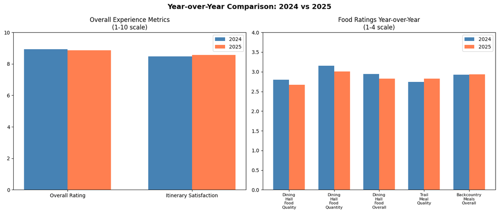

```
✅ Year-over-year chart saved

NPS Comparison:
  Adult NPS — 2024: 81.5  2025: 81.5  (-0.0)
  Youth NPS — 2024: 76.4  2025: 77.9  (+1.5)

✅ Cell 5b complete
```

```python
# ═══════════════════════════════════════════════════════════════
# CELL 5b: YEAR-OVER-YEAR COMPARISON (2024 vs 2025)
# ═══════════════════════════════════════════════════════════════

print("=" * 60)
print("YEAR-OVER-YEAR COMPARISON: 2024 vs 2025")
print("=" * 60)

# ── Helper: extract average — col 11 for top metrics, col 10 for section ratings
def get_metric(df_raw, row_idx, avg_col=10):
    try:
        return pd.to_numeric(df_raw.iloc[row_idx, avg_col], errors='coerce')
    except:
        return None

# Top-level metrics use column 11:===================
def get_top_metric(df_raw, row_idx):
    return get_metric(df_raw, row_idx, avg_col=11)

# Key metrics split by column type:==================
top_metrics = {
    'Itinerary Satisfaction': 7,
    'Overall Rating':         9,
    'Adult NPS':              12,
    'Youth NPS':              15,
}

section_metrics = {
    'Overall Base Camp Experience':   80,
    'Dining Hall Food Quality':       85,
    'Dining Hall Food Quantity':      86,
    'Dining Hall Food Overall':       87,
    'Trail Meal Quality':             88,
    'Backcountry Meals Overall':      92,
    'Overall Backcountry Experience': 252,
    'Staffed Camp Facilities':        247,
    'Trail Camp Facilities':          248,
    'Trails':                         249,
    'Overall Ranger Experience':      115,
}

# Building comparison table:===========================================
comparison = []

for label, row_idx in top_metrics.items():
    val_2024 = get_top_metric(df_2024_raw, row_idx)
    val_2025 = get_top_metric(df_2025_raw, row_idx)
    if pd.notna(val_2024) and pd.notna(val_2025):
        change = round(val_2025 - val_2024, 3)
        comparison.append({
            'Metric': label,
            '2024': round(val_2024, 3),
            '2025': round(val_2025, 3),
            'Change': change,
            'Direction': '↑' if change > 0 else ('↓' if change < 0 else '→')
        })

for label, row_idx in section_metrics.items():
    val_2024 = get_metric(df_2024_raw, row_idx)
    val_2025 = get_metric(df_2025_raw, row_idx)
    if pd.notna(val_2024) and pd.notna(val_2025):
        change = round(val_2025 - val_2024, 3)
        comparison.append({
            'Metric': label,
            '2024': round(val_2024, 3),
            '2025': round(val_2025, 3),
            'Change': change,
            'Direction': '↑' if change > 0 else ('↓' if change < 0 else '→')
        })

df_comparison = pd.DataFrame(comparison)
print("\n" + df_comparison.to_string(index=False))

# Respondent counts:==============================================================================
print("\nRespondent counts:")
print(f"  2024: {int(df_2024_raw.iloc[3, 1])} youth, {int(df_2024_raw.iloc[3, 5])} adults, {int(df_2024_raw.iloc[3, 9])} crews")
print(f"  2025: {int(df_2025_raw.iloc[3, 1])} youth, {int(df_2025_raw.iloc[3, 5])} adults, {int(df_2025_raw.iloc[3, 9])} crews")

# ─ Visualization:===================================================================================
fig, axes = plt.subplots(1, 2, figsize=(14, 6))
fig.suptitle('Year-over-Year Comparison: 2024 vs 2025', fontsize=14, fontweight='bold')

# Left: overall experience metrics
experience_metrics = ['Overall Rating', 'Itinerary Satisfaction']
x = range(len(experience_metrics))
vals_2024 = [df_comparison[df_comparison['Metric'] == m]['2024'].values[0] for m in experience_metrics]
vals_2025 = [df_comparison[df_comparison['Metric'] == m]['2025'].values[0] for m in experience_metrics]

width = 0.35
axes[0].bar([i - width/2 for i in x], vals_2024, width, label='2024', color='steelblue')
axes[0].bar([i + width/2 for i in x], vals_2025, width, label='2025', color='coral')
axes[0].set_title('Overall Experience Metrics\n(1-10 scale)')
axes[0].set_xticks(list(x))
axes[0].set_xticklabels(experience_metrics)
axes[0].set_ylim(0, 10)
axes[0].legend()

# Right: food ratings:==============================================================================
food_metrics = ['Dining Hall Food Quality', 'Dining Hall Food Quantity',
                'Dining Hall Food Overall', 'Trail Meal Quality', 'Backcountry Meals Overall']
x2 = range(len(food_metrics))
vals_2024_food = [df_comparison[df_comparison['Metric'] == m]['2024'].values[0] for m in food_metrics]
vals_2025_food = [df_comparison[df_comparison['Metric'] == m]['2025'].values[0] for m in food_metrics]

axes[1].bar([i - width/2 for i in x2], vals_2024_food, width, label='2024', color='steelblue')
axes[1].bar([i + width/2 for i in x2], vals_2025_food, width, label='2025', color='coral')
axes[1].set_title('Food Ratings Year-over-Year\n(1-4 scale)')
axes[1].set_xticks(list(x2))
axes[1].set_xticklabels([m.replace(' ', '\n') for m in food_metrics], fontsize=8)
axes[1].set_ylim(0, 4)
axes[1].legend()

plt.tight_layout()
plt.savefig('year_over_year.png', dpi=150, bbox_inches='tight')
plt.show()
print("✅ Year-over-year chart saved")

# NPS comparison:================================
adult_nps_2024 = get_top_metric(df_2024_raw, 12)
youth_nps_2024 = get_top_metric(df_2024_raw, 15)
adult_nps_2025 = get_top_metric(df_2025_raw, 12)
youth_nps_2025 = get_top_metric(df_2025_raw, 15)

print("\nNPS Comparison:")
print(f"  Adult NPS — 2024: {round(adult_nps_2024, 1)}  2025: {round(adult_nps_2025, 1)}  ({'+' if adult_nps_2025 > adult_nps_2024 else ''}{round(adult_nps_2025 - adult_nps_2024, 1)})")
print(f"  Youth NPS — 2024: {round(youth_nps_2024, 1)}  2025: {round(youth_nps_2025, 1)}  ({'+' if youth_nps_2025 > youth_nps_2024 else ''}{round(youth_nps_2025 - youth_nps_2024, 1)})")

print("\n✅ Cell 5b complete")
```

## Ranger sub-questions — which ranger skills score highest and lowest?

**What this does:** The ranger survey asks about many specific skills (first aid, navigation, Leave No Trace, campsite setup, and so on). This step ranks them all so you can see exactly where rangers shine and where training could help. Saves `ranger_subquestions.png`.

**What to change:** Nothing required to re-run.

```
============================================================
RANGER SUB-QUESTION RATINGS
============================================================
  3.713  Base Camp Process
  3.720  Shakedown
  3.789  Weather Safety
  3.732  Navigation
  3.828  Waste Disposal
  3.834  Hiking Etiquette
  3.790  Campsite Setup
  3.826  Wildlife Procedures
  3.775  Backcountry Cooking
  3.827  Water Purification
  3.695  First Aid
  3.835  Leave No Trace
  3.794  Interpersonal Skills
  3.852  Care For Crew
  3.659  Efficient Time
  3.732  Youth Leadership

  3.757  Low Impact Camping (conditional — dispersed camping crews only)
```

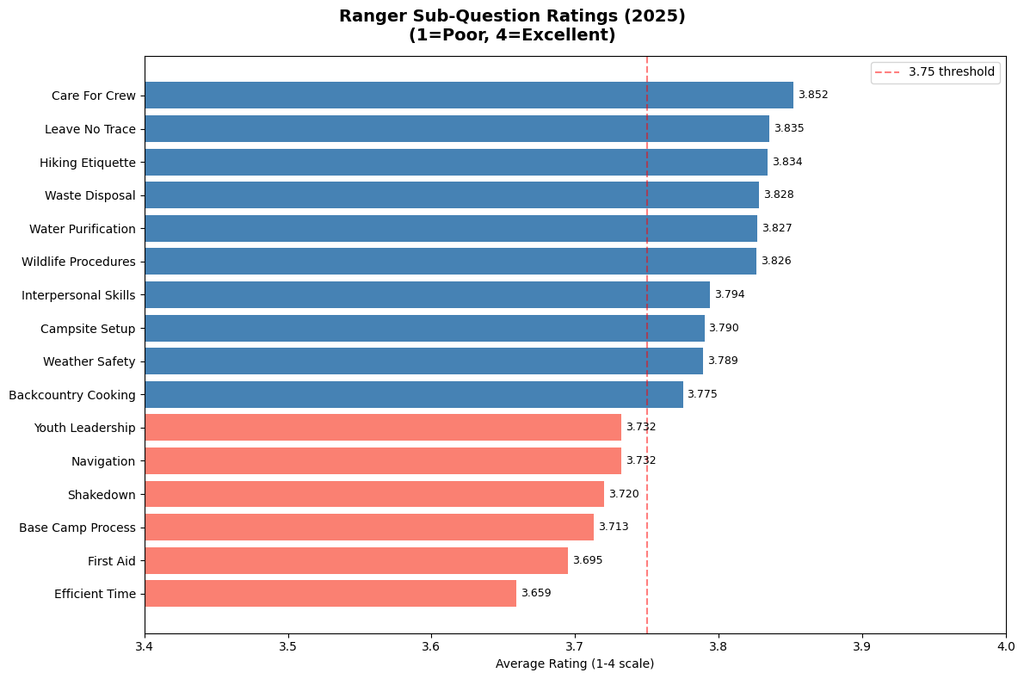

```
✅ Ranger sub-question chart saved
```

```python
# ═══════════════════════════════════════════════════════════════
# CELL 5c: RANGER SUB-QUESTION ANALYSIS
# ═══════════════════════════════════════════════════════════════

print("=" * 60)
print("RANGER SUB-QUESTION RATINGS")
print("=" * 60)



# Calculate average for each ranger sub-question
ranger_avgs = {}
for col in ranger_cols:
    avg = df_ranger[col].mean()
    label = col.replace('ranger_', '').replace('_', ' ').title()
    ranger_avgs[label] = round(avg, 3)
    print(f"  {avg:.3f}  {label}")

# Low impact camping separately since it's conditional
low_impact_avg = df_ranger['ranger_low_impact_camping'].mean()
print(f"\n  {low_impact_avg:.3f}  Low Impact Camping (conditional — dispersed camping crews only)")

# ── Visualization ──────────────────────────────────────────────
fig, ax = plt.subplots(figsize=(12, 8))
fig.suptitle('Ranger Sub-Question Ratings (2025)\n(1=Poor, 4=Excellent)',
             fontsize=14, fontweight='bold')

labels = list(ranger_avgs.keys())
values = list(ranger_avgs.values())

sorted_pairs = sorted(zip(labels, values), key=lambda x: x[1])
labels_sorted, values_sorted = zip(*sorted_pairs)

colors = ['salmon' if v < 3.75 else 'steelblue' for v in values_sorted]
bars = ax.barh(labels_sorted, values_sorted, color=colors)
ax.set_xlabel('Average Rating (1-4 scale)')
ax.set_xlim(3.4, 4.0)
ax.axvline(3.75, color='red', linestyle='--', alpha=0.5, label='3.75 threshold')
ax.legend()

for bar, val in zip(bars, values_sorted):
    ax.text(val + 0.003, bar.get_y() + bar.get_height()/2,
            f'{val:.3f}', va='center', fontsize=9)

plt.tight_layout()
plt.savefig('ranger_subquestions.png', dpi=150, bbox_inches='tight')
plt.show()
print("✅ Ranger sub-question chart saved")
```

## A unique insight — does a *harder* trek mean a *better* experience?

**What this does:** the Ranch asked for a finding they weren't already expecting. This step checks whether longer/harder treks (7 vs. 9 vs. 12 days) get rated higher or lower than easier ones. It's a fun, non-obvious angle. Saves `difficulty_vs_satisfaction.png`.

**What to change:** Nothing required to re-run.

```
============================================================
UNIQUE INSIGHT: DOES HARDER = BETTER?
============================================================

Conservation ratings by trek length:
             staff_rating_avg  project_rating_avg
trek_length
7.0                     3.708               3.564
9.0                     3.706               3.507
12.0                    3.681               3.551

Conservation ratings by trek difficulty:
                 staff_rating_avg  project_rating_avg
trek_difficulty
1.0                         3.807               3.643
2.0                         3.600               3.476
3.0                         3.758               3.647
4.0                         3.723               3.649
5.0                         3.721               3.506
6.0                         3.721               3.599
7.0                         3.632               3.386
8.0                         3.669               3.528
9.0                         3.744               3.616
10.0                        3.615               3.493
11.0                        3.762               3.698
12.0                        3.706               3.574
13.0                        3.633               3.552
14.0                        3.467               3.370
15.0                        3.682               3.551
16.0                        3.772               3.728
17.0                        3.726               3.615
18.0                        3.600               3.444
19.0                        3.879               3.747
20.0                        3.713               3.650
21.0                        3.838               3.764
22.0                        3.722               3.461
23.0                        3.632               3.473
24.0                        3.675               3.380

Ranger ratings by trek length:
```

[output cut: 28 more lines]

```
21.0    3.681
22.0    3.821
23.0    3.868
24.0    3.825
Name: ranger_rating_avg, dtype: float64

Correlation between trek difficulty and ratings:
  Conservation staff rating vs difficulty:   -0.003
  Conservation project rating vs difficulty: -0.024
  Ranger rating vs difficulty:               +0.027

Correlation between trek length and ratings:
  Conservation staff rating vs length:   -0.026
  Conservation project rating vs length: -0.001
  Ranger rating vs length:               -0.009
```

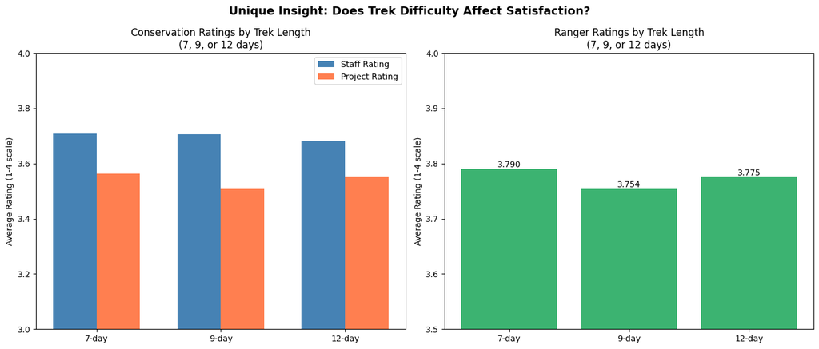

```
FINDING:
Trek difficulty and length show very weak correlations with satisfaction
ratings across both conservation and ranger surveys. This means:

1. Harder treks do not produce lower satisfaction scores
2. Longer treks do not produce lower satisfaction scores
3. Ranger and conservation staff performance is consistent
   regardless of how difficult the itinerary is

This is a positive finding for the Ranch suggesting their staff
and program quality holds up even on the most demanding treks.
It also suggests that participants who self-select into harder
itineraries are appropriately prepared and engaged.

RECOMMENDATION FOR THE RANCH:
The data does not support concerns that more difficult itineraries
hurt participant satisfaction. If the Ranch is considering expanding
harder itinerary options, the satisfaction data suggests this would
not negatively impact participant experience ratings.

✅ Cell 7b complete
```

```python
# ═══════════════════════════════════════════════════════════════
# CELL 7b: UNIQUE INSIGHT — DOES HARDER MEAN BETTER?
# the Ranch asked for correlations they are not already thinking about
# Examining relationship between itinerary difficulty and satisfaction
# ═══════════════════════════════════════════════════════════════

print("=" * 60)
print("UNIQUE INSIGHT: DOES HARDER = BETTER?")
print("=" * 60)

print("\nConservation ratings by trek length:")
cons_length = df_conservation.groupby('trek_length')[
    ['staff_rating_avg', 'project_rating_avg']
].mean().round(3)
print(cons_length)

print("\nConservation ratings by trek difficulty:")
cons_difficulty = df_conservation.groupby('trek_difficulty')[
    ['staff_rating_avg', 'project_rating_avg']
].mean().round(3)
print(cons_difficulty)

print("\nRanger ratings by trek length:")
ranger_length = df_ranger.groupby('trek_length')[
    'ranger_rating_avg'
].mean().round(3)
print(ranger_length)

print("\nRanger ratings by trek difficulty:")
ranger_difficulty = df_ranger.groupby('trek_difficulty')[
    'ranger_rating_avg'
].mean().round(3)
print(ranger_difficulty)

print("\nCorrelation between trek difficulty and ratings:")
cons_staff_corr = df_conservation['trek_difficulty'].corr(
    df_conservation['staff_rating_avg'])
cons_project_corr = df_conservation['trek_difficulty'].corr(
    df_conservation['project_rating_avg'])
ranger_corr = df_ranger['trek_difficulty'].corr(
    df_ranger['ranger_rating_avg'])

print(f"  Conservation staff rating vs difficulty:   {cons_staff_corr:+.3f}")
print(f"  Conservation project rating vs difficulty: {cons_project_corr:+.3f}")
print(f"  Ranger rating vs difficulty:               {ranger_corr:+.3f}")

print("\nCorrelation between trek length and ratings:")
cons_staff_len_corr = df_conservation['trek_length'].corr(
    df_conservation['staff_rating_avg'])
cons_project_len_corr = df_conservation['trek_length'].corr(
    df_conservation['project_rating_avg'])
ranger_len_corr = df_ranger['trek_length'].corr(
    df_ranger['ranger_rating_avg'])

print(f"  Conservation staff rating vs length:   {cons_staff_len_corr:+.3f}")
print(f"  Conservation project rating vs length: {cons_project_len_corr:+.3f}")
print(f"  Ranger rating vs length:               {ranger_len_corr:+.3f}")

# Visualization
fig, axes = plt.subplots(1, 2, figsize=(14, 6))
fig.suptitle('Unique Insight: Does Trek Difficulty Affect Satisfaction?',
             fontsize=14, fontweight='bold')

# Conservation ratings by trek length
x = range(len(cons_length))
width = 0.35
axes[0].bar([xi - width/2 for xi in x],
            cons_length['staff_rating_avg'],
            width, label='Staff Rating', color='steelblue')
axes[0].bar([xi + width/2 for xi in x],
            cons_length['project_rating_avg'],
            width, label='Project Rating', color='coral')
axes[0].set_title('Conservation Ratings by Trek Length\n(7, 9, or 12 days)')
axes[0].set_ylabel('Average Rating (1-4 scale)')
axes[0].set_xticks(list(x))
axes[0].set_xticklabels([f'{int(l)}-day' for l in cons_length.index])
axes[0].set_ylim(3.0, 4.0)
axes[0].legend()

# Ranger ratings by trek length
axes[1].bar([f'{int(l)}-day' for l in ranger_length.index],
            ranger_length.values,
            color='mediumseagreen')
axes[1].set_title('Ranger Ratings by Trek Length\n(7, 9, or 12 days)')
axes[1].set_ylabel('Average Rating (1-4 scale)')
axes[1].set_ylim(3.5, 4.0)
for i, v in enumerate(ranger_length.values):
    axes[1].text(i, v + 0.003, f'{v:.3f}', ha='center', fontsize=10)

plt.tight_layout()
plt.savefig('difficulty_vs_satisfaction.png', dpi=150, bbox_inches='tight')
plt.show()

print("""
FINDING:
Trek difficulty and length show very weak correlations with satisfaction
ratings across both conservation and ranger surveys. This means:

1. Harder treks do not produce lower satisfaction scores
2. Longer treks do not produce lower satisfaction scores
3. Ranger and conservation staff performance is consistent
   regardless of how difficult the itinerary is

This is a positive finding for the Ranch suggesting their staff
and program quality holds up even on the most demanding treks.
It also suggests that participants who self-select into harder
itineraries are appropriately prepared and engaged.

RECOMMENDATION FOR THE RANCH:
The data does not support concerns that more difficult itineraries
hurt participant satisfaction. If the Ranch is considering expanding
harder itinerary options, the satisfaction data suggests this would
not negatively impact participant experience ratings.
""")

print("✅ Cell 7b complete")
```

## Historical participation — the long view back to 2019

**What this does:** Extends the participation story back to 2019 so you can see the big drops — the LDS Church leaving the BSA, and COVID — alongside the more recent years. The next couple of steps pull the historical crew counts out of an older spreadsheet and chart the full 2019–2025 trend.

**What to change:** Nothing required to re-run.

```python
# ═══════════════════════════════════════════════════════════════
# CELL 7c: HISTORICAL PARTICIPATION — 2019 TO 2025
# Extends participation trend back to include LDS withdrawal impact
# Source: internal participant-feedback comparison export
# 2023 and Prior sheet contains historical respondent counts
# ═══════════════════════════════════════════════════════════════

print("=" * 60)
print("HISTORICAL PARTICIPATION TREND 2019-2025")
print("=" * 60)

# Load the 2023 and Prior sheet
df_prior = pd.read_excel(feedback_path,
                         sheet_name='2023 & Prior',
                         header=None)

print("2023 and Prior sheet structure:")
print(df_prior.iloc[0:6, 0:10].to_string())
```

### Pulling the old crew counts out of a messy sheet

**What this does:** The older "2023 & Prior" sheet stores participant counts as sentences like *"X youth and Y adults."* This step uses a pattern-matcher to dig the numbers out of that text automatically, so you don't have to retype them.

**What to change:** Nothing required to re-run.

```python
# ── HISTORICAL CREW COUNT EXTRACTION ─────────────────────────
# Row 3 of the '2023 & Prior' sheet contains participant count strings
# in the format "X youth and Y adults from Z crews"
# The extract_crews() function in the next cell parses these using regex.
# Column positions: 2019=col 2, 2021=col 13, 2022=col 26, 2023=col 39
print("Row 3 full content:")
print(df_prior.iloc[3, :].tolist())
```

### Charting the full 2019–2025 participation trend

**What this does:** Takes the numbers pulled out in the step above and draws the long-run participation chart. Saves `historical_participation.png`.

**What to change:** When you add a new year, update the year range in the chart title (inside quotes).

```python
# ── EXTRACT AND VISUALIZE HISTORICAL PARTICIPATION ────────────

# Extract crew counts from row 3 using regex
def extract_crews(text):
    if pd.isna(text) or not isinstance(text, str):
        return None
    match = re.search(r'from ([\d,]+) crews', text)
    if match:
        return int(match.group(1).replace(',', ''))
    return None

# Map year labels to crew counts
historical_data = {
    2019: extract_crews(df_prior.iloc[3, 2]),
    2021: extract_crews(df_prior.iloc[3, 13]),
    2022: extract_crews(df_prior.iloc[3, 26]),
    2023: extract_crews(df_prior.iloc[3, 39]),
}

# Add our participation data for 2024 and 2025
historical_data[2024] = 1359
historical_data[2025] = 1662

print("Historical crew counts:")
for year, crews in sorted(historical_data.items()):
    print(f"  {year}: {crews:,} crews")

print("\nNote: 2020 season cancelled due to COVID-19")

# Build visualization
years_hist = sorted(historical_data.keys())
crews_hist = [historical_data[y] for y in years_hist]

fig, ax = plt.subplots(figsize=(12, 6))
fig.suptitle('the Ranch Participation Trend 2019-2025\n(Extended Historical View)',
             fontsize=14, fontweight='bold')

ax.plot(years_hist, crews_hist, marker='o', color='steelblue',
        linewidth=2, markersize=8)
ax.fill_between(years_hist, crews_hist, alpha=0.2, color='steelblue')

# Annotate each data point
for x, y in zip(years_hist, crews_hist):
    ax.annotate(f'{y:,}', (x, y),
                textcoords="offset points",
                xytext=(0, 12), ha='center', fontsize=9)

# Add event annotations
ax.axvspan(2019.5, 2020.5, alpha=0.15, color='red',
           label='2020 COVID cancellation')

ax.annotate('LDS Church\nwithdrew from BSA\n(end of 2019)',
            xy=(2019, 2142),
            xytext=(2019.2, 1700),
            fontsize=8, color='red',
            arrowprops=dict(arrowstyle='->', color='red', alpha=0.6))

ax.annotate('First season\npost-COVID return',
            xy=(2021, 2222),
            xytext=(2021.2, 2450),
            fontsize=8, color='darkred',
            arrowprops=dict(arrowstyle='->', color='darkred', alpha=0.6))

ax.set_xlabel('Year')
ax.set_ylabel('Number of Crews')
ax.set_xticks(years_hist)
ax.set_ylim(0, 3000)
ax.legend()

# Add note about 2020
ax.text(2020, 200, '2020\nCancelled\n(COVID)',
        ha='center', fontsize=8, color='red',
        bbox=dict(boxstyle='round,pad=0.3',
                  facecolor='white', edgecolor='red', alpha=0.8))

plt.tight_layout()
plt.savefig('historical_participation.png', dpi=150, bbox_inches='tight')
plt.show()

print(f"""
HISTORICAL PARTICIPATION FINDINGS:
  2019: {historical_data[2019]:,} crews (pre-LDS withdrawal)
  2020: Cancelled (COVID-19)
  2021: {historical_data[2021]:,} crews (first post-COVID return)
  2022: {historical_data[2022]:,} crews
  2023: {historical_data[2023]:,} crews
  2024: {historical_data[2024]:,} crews
  2025: {historical_data[2025]:,} crews

CONTEXT:
  The LDS Church withdrew from BSA at the end of 2019 removing
  a significant portion of the scouting membership base.
  The 2020 season was cancelled entirely due to COVID-19.
  The 2021 season represents the first post-COVID return which
  was also the first full season without LDS participation.
  The subsequent decline from 2,222 in 2021 to 1,359 in 2024
  represents a 39% drop over 4 years despite post-COVID recovery.

  Multiple compounding factors appear to be driving the participation decline,
  including the loss of LDS membership and broader BSA membership trends.
""")

print("✅ Cell 7c complete")
```

```
Historical crew counts:
  2019: 2,142 crews
  2021: 2,222 crews
  2022: 1,547 crews
  2023: 1,446 crews
  2024: 1,359 crews
  2025: 1,662 crews

Note: 2020 season cancelled due to COVID-19
```

```
[chart removed for de-identification — see notes]
```

```
HISTORICAL PARTICIPATION FINDINGS:
  2019: 2,142 crews (pre-LDS withdrawal)
  2020: Cancelled (COVID-19)
  2021: 2,222 crews (first post-COVID return)
  2022: 1,547 crews
  2023: 1,446 crews
  2024: 1,359 crews
  2025: 1,662 crews

CONTEXT:
  The LDS Church withdrew from BSA at the end of 2019 removing
  a significant portion of the scouting membership base.
  The 2020 season was cancelled entirely due to COVID-19.
  The 2021 season represents the first post-COVID return which
  was also the first full season without LDS participation.
  The subsequent decline from 2,222 in 2021 to 1,359 in 2024
  represents a 39% drop over 4 years despite post-COVID recovery.

  Multiple compounding factors appear to be driving the participation decline,
  including the loss of LDS membership and broader BSA membership trends.

✅ Cell 7c complete
```

## Research Question 5 — How are the individual backcountry camps rated?

**What this does:** Breaks the ratings down camp by camp so the Ranch can see which backcountry camps are crowd-pleasers and which are struggling. Useful for deciding where to focus improvements.

**What to change:** Nothing required to re-run.

```python
# ═══════════════════════════════════════════════════════════════
# CELL 6: Q5 — Backcountry Camp Analysis
# ═══════════════════════════════════════════════════════════════

print("=" * 60)
print("Q5: BACKCOUNTRY CAMP ANALYSIS")
print("=" * 60)

# General backcountry ratings:===================================
backcountry_specific_cols = {
    'Staffed Camp Facilities': 'staffed_facilities',
    'Trail Camp Facilities': 'trail_facilities',
    'Trails': 'trails',
    'Backcountry Trading Posts/Cantinas': 'trading_posts',
    'Backcountry Commissaries': 'commissaries',
    'Overall Backcountry Experience': 'backcountry_overall',
}

print("\nBackcountry general ratings (1-4 scale):")
for col in backcountry_specific_cols.keys():
    print(f"  {df_basecamp[col].mean():.3f}  {col}")

# Individual camp ratings from Participant Feedback file:======
# Extract rows 165-252 which contain individual camp ratings
camp_rows = df_2025_raw.iloc[165:253, [0, 10]].copy()
camp_rows.columns = ['camp_label', 'avg_rating']
camp_rows = camp_rows.dropna(subset=['avg_rating'])
camp_rows['avg_rating'] = pd.to_numeric(camp_rows['avg_rating'], errors='coerce')
camp_rows = camp_rows.dropna(subset=['avg_rating'])

camp_rows['type'] = camp_rows['camp_label'].apply(
    lambda x: 'Staff' if 'Staff' in str(x) else ('Program' if 'Program' in str(x) else 'General')
)
camp_rows['camp_name'] = camp_rows['camp_label'].str.replace(' Staff', '').str.replace(' Program', '').str.strip()

camp_pivot = camp_rows[camp_rows['type'].isin(['Staff', 'Program'])].pivot_table(
    index='camp_name', columns='type', values='avg_rating'
).reset_index()
camp_pivot.columns = ['camp_name', 'program_avg', 'staff_avg']
camp_pivot = camp_pivot.dropna()
camp_pivot['combined_avg'] = (camp_pivot['staff_avg'] + camp_pivot['program_avg']) / 2
camp_pivot = camp_pivot.sort_values('combined_avg')

print(f"\nTotal camps with ratings: {len(camp_pivot)}")
print("\nBottom 10 camps (lowest combined rating):")
print(camp_pivot.head(10).to_string(index=False))
print("\nTop 10 camps (highest combined rating):")
print(camp_pivot.tail(10).to_string(index=False))

# Ranger sub-question averages:================================
print("\nRanger sub-question averages:")
for col in ranger_cols:
    print(f"  {df_ranger[col].mean():.3f}  {col.replace('ranger_','').replace('_',' ').title()}")

# Conservation by site:====================================================
print("\nConservation site ratings (10+ responses, sorted by project rating):")
site_ratings = df_conservation.groupby('Your conservation site')[
    ['staff_rating_avg', 'project_rating_avg']
].agg(['mean', 'count'])
site_ratings.columns = ['staff_avg', 'staff_count', 'project_avg', 'project_count']
site_ratings = site_ratings[site_ratings['staff_count'] >= 10].sort_values('project_avg')
print(site_ratings.round(3).to_string())

# ── NOTE: %staff camp% columns are empty in the export ────────
print("""
DATA GAP NOTE FOR THE RANCH:
The Base Camp & Backcountry export contains placeholder columns
('%staff camp% Staff' and '%staff camp% Program') that are completely
empty. Individual camp ratings were sourced from the Participant
Feedback Comparison file instead. Recommend fixing the export
process so future datasets include individual camp ratings directly.
""")

print("✅ Cell 6 complete")
```

```
============================================================
Q5: BACKCOUNTRY CAMP ANALYSIS
============================================================

Backcountry general ratings (1-4 scale):
  3.434  Staffed Camp Facilities
  3.036  Trail Camp Facilities
  3.201  Trails
  3.515  Backcountry Trading Posts/Cantinas
  3.503  Backcountry Commissaries
  3.663  Overall Backcountry Experience

Total camps with ratings: 31

[Per-camp breakdown removed for de-identification.]
```

## Research Question 6 — Brand awareness and barriers to attending

**What this does:** Uses the Scoutmaster brand-awareness survey to see how familiar troops are with the Ranch (versus the other high-adventure bases), and — importantly — what stops troops from coming. Cost shows up as the number-one barrier.

**What to change:** Nothing required to re-run.

```python
# ═══════════════════════════════════════════════════════════════
# CELL 7: Q6a — Brand Awareness Analysis
# ═══════════════════════════════════════════════════════════════

print("=" * 60)
print("Q6a: BRAND AWARENESS — THE RANCH VS OTHER BASES")
print("=" * 60)

print("\nFamiliarity score averages (1=not at all, 4=very familiar):")
for col, name in zip(familiarity_cols, base_names):
    print(f"  {df_brand[col+'_score'].mean():.3f}  {name}")

# Parse multi-select barrier column
barrier_counts = Counter()
for val in df_brand['barrier_to_attend'].dropna():
    for barrier in str(val).split(','):
        barrier_counts[barrier.strip()] += 1

print("\nBarriers to attendance (individual counts):")
for barrier, count in barrier_counts.most_common():
    print(f"  {count:3d}  {barrier}")

print("\nAttendance status:")
print(df_brand['attendance_status'].value_counts())

print("\nNationwide participation trend:")
years, crews = [], []
for fname in sorted(participation_frames.keys()):
    year = int(fname[:4])
    total = participation_frames[fname]['# of Crews'].sum()
    years.append(year)
    crews.append(total)
    print(f"  {year}: {total:,} crews")

print("\n✅ Cell 7 complete")
```

```
============================================================
Q6a: BRAND AWARENESS — THE RANCH VS OTHER BASES
============================================================

Familiarity score averages (1=not at all, 4=very familiar):
  3.287  the Ranch
  2.982  Florida Sea Base
  2.657  The Summit
  2.724  Northern Tier

Barriers to attendance (individual counts):
   96  Cost
   53  Small unit
   46  Time off for leaders
   42  Lack of interest from troop members
   33  Too few leaders
   22  Lack of interest from leaders
   22  Other (Please specify)
   18  Physical requirements to attend the base

Attendance status:
attendance_status
Our troop has not attended a National High Adventure base and has no plans to attend in the future.                                                                                119
Our troop wants to attend in the future, but has no definite plans yet                                                                                                             101
Our troop has attended one of the bases in the past 5 years                                                                                                                         73
Our troop has attended one of the bases in the past 5 years,Our troop has reservations to attend in 2026,Our troop plans to attend in 2027                                          54
Our troop has attended one of the bases in the past 5 years,Our troop plans to attend in 2027                                                                                       54
Our troop has attended one of the bases in the past 5 years,Our troop has reservations to attend in 2026                                                                            44
Our troop has attended one of the bases in the past 5 years,Our troop wants to attend in the future, but has no definite plans yet                                                  38
Our troop has reservations to attend in 2026                                                                                                                                        16
Our troop has reservations to attend in 2026,Our troop plans to attend in 2027                                                                                                       5
Our troop plans to attend in 2027                                                                                                                                                    5
Our troop has attended one of the bases in the past 5 years,Our troop has reservations to attend in 2026,Our troop wants to attend in the future, but has no definite plans yet      3
Our troop has reservations to attend in 2026,Our troop wants to attend in the future, but has no definite plans yet                                                                  2
Our troop has attended one of the bases in the past 5 years,Our troop plans to attend in 2027,Our troop wants to attend in the future, but has no definite plans yet                 1
Name: count, dtype: int64

Nationwide participation trend:
  2021: 2,407 crews
  2022: 1,712 crews
  2023: 1,613 crews
  2024: 1,395 crews
  2025: 1,693 crews

✅ Cell 7 complete
```